# 麻雀の強さを分析する

UPDATE: 2024-01-26 18:04:07.556405

# はじめに

このノートは「ベイズ統計」に関する何らかの内容をまとめ、ベイズ統計への理解を深めていくために作成している。今回は「たのしいベイズモデリング」の第18章に記載されている「本当に麻雀が強いのは誰か？」の内容を参考にさせていただき、写経しながら、ところどころ自分用の補足をメモすることで、自分用の補足資料になることを目指す。私の解釈がおかしく、メモが誤っている場合があるので注意。

- [実験！たのしいベイズモデリング1](https://www.kitaohji.com/book/b580209.html)

# 準備

まずは必要なライブラリや設定を行う。使用するデータは4人の麻雀の143ゲーム分の結果データを利用する。

```r
library(tidyverse)
library(rstan)
library(patchwork)
library(MCMCpack)

options(max.print = 999999)
rstan_options(auto_write=TRUE)
options(mc.cores=parallel::detectCores())

pointData <- read_csv('~/Desktop/pointData.csv')
head(pointData, 10)
```

```
## # A tibble: 10 × 4
##    player_A player_B player_C player_D
##       <dbl>    <dbl>    <dbl>    <dbl>
##  1       10      -26       66      -50
##  2        5      -38      -24       57
##  3      -23       45      -34       12
##  4      -39       44        9      -14
##  5      -20       55        2      -37
##  6      -19        6       54      -41
##  7       -3       97      -63      -31
##  8      -32      114        3      -85
##  9        9      -14      -36       41
## 10      -14       42      -34        6
```

各プレイヤーの点数は下記の通りである。プレイヤーCが少し弱くみえる。

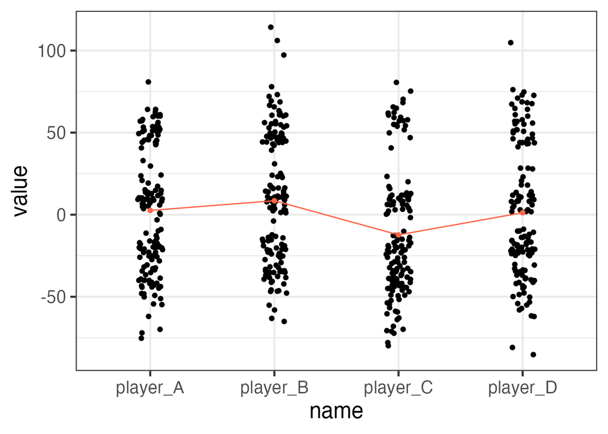

```r
pointData %>%
  pivot_longer(cols = everything()) %>%
  ggplot(., aes(name, value, group = 1)) +
  theme_bw(base_size = 18) +
  geom_jitter(width = 0.1) +
  stat_summary(fun.y = mean, geom = 'point', col = 'tomato') +
  stat_summary(fun.y = mean, geom = 'line', col = 'tomato')
```

## 分析

タイトルの通り「本当に麻雀が強いのは誰か？」を推定すること。そのためにディリクレ分布を使ったモデルを考える。ディリクレ分布は下記の通り。$V$は次元数、$\boldsymbol{\beta} = (\beta_1, \beta_2, \cdots, \beta_V)$はパラメタ、確率変数の実現値$\boldsymbol{\phi} = (\phi_1, \phi_2, \cdots, \phi_V)$である。$\boldsymbol{\phi}$の総和は1となる。$C$は正規化係数で、$\Gamma(x)$はガンマ関数。

$$\begin{aligned}
C &= \frac{\Gamma(\sum_{v=1}^V \beta_v)}{\prod_{v=1}^V
\Gamma(\beta_v)} \\
\mathrm{Dirichlet}(\boldsymbol{\phi} | \boldsymbol{\beta}) &= C
\prod_{v=1}^V \phi_v^{\beta_v-1}
\end{aligned}$$

Wikipediaによると、

> ベータ分布を多変量に拡張して一般化した形をしており、そのため多変量ベータ分布とも呼ばれる。

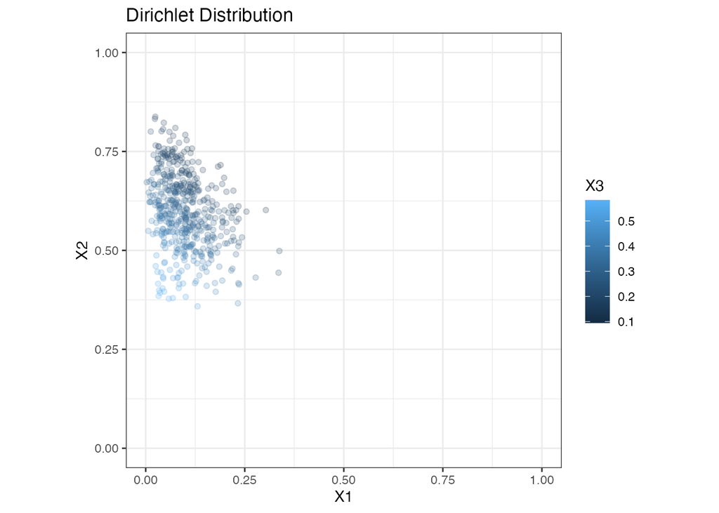

```r
data.frame(rdirichlet(500, c(2.5, 15, 7.5))) %>%
  ggplot(., aes(x = X1, y = X2, col = X3)) +
  geom_point(alpha = 0.2) +
  labs(title = 'Dirichlet Distribution') +
  scale_x_continuous(limits = c(0, 1)) +
  scale_y_continuous(limits = c(0, 1)) +
  coord_fixed() +
  theme_bw()
```

なぜディリクレ分布をここで利用するのかというと、麻雀の点数ルールが関わっている。25000点の30000点返しというルールであれば、30000点を基準として考える。例えば、下記の結果となった場合、

- player1: 5000 - 30000 = -25000 => -25000/100 = -25
- player2: 18000 - 30000 = -12000 => -12000/100 = -12
- player3: 32000 - 30000 = 2000 => 2000/100 = +2
- player4: (-25）+（-12）+ (+2）= -35 => +35

であり、これらの総和は0になる。

```r
- 25 - 12 + 2 + 35
```

```
## [1] 0
```

麻雀のポイント合計は常に0であるため、ポイントにソフトマックス関数を適用して、各ゲームごとの総和が1になるように調整する。そうすることでディリクレ分布のパラメタの総和が1になるという条件の元、推定が可能になる。

$$\begin{eqnarray}
point_{it} = \frac{exp[\alpha_{it}]}{\sum^{4}_{i} exp[\alpha_{it}]}
\end{eqnarray}$$

変換したデータはこちら。

```r
# 前処理
playerNum <- ncol(pointData)  # num of player
hantyanNum <- nrow(pointData) # num of game

# 値が大きいので、小さくしてから変換
point_mod <- as.matrix(pointData/100)
point <- matrix(0, hantyanNum, playerNum)
for(h in 1:hantyanNum){
  point[h,] <- exp(point_mod[h,])/sum(exp(point_mod[h,]))
}

head(point)
```

```
##           [,1]      [,2]      [,3]      [,4]
## [1,] 0.2501776 0.1745430 0.4379790 0.1373004
## [2,] 0.2450500 0.1594072 0.1833620 0.4121808
## [3,] 0.1890795 0.3732199 0.1693839 0.2683166
## [4,] 0.1614617 0.3702832 0.2609341 0.2073209
## [5,] 0.1920587 0.4065883 0.2393199 0.1620332
## [6,] 0.1937374 0.2487638 0.4020208 0.1554779
```

総和が1になっていることがわかる。

```r
apply(point, 1, sum)
```

```
##   [1] 1 1 1 1 1 1 1 1 1 1 1 1 1 1 1 1 1 1 1 1 1 1 1 1 1 1 1 1 1 1 1 1 1 1 1 1 1
##  [38] 1 1 1 1 1 1 1 1 1 1 1 1 1 1 1 1 1 1 1 1 1 1 1 1 1 1 1 1 1 1 1 1 1 1 1 1 1
##  [75] 1 1 1 1 1 1 1 1 1 1 1 1 1 1 1 1 1 1 1 1 1 1 1 1 1 1 1 1 1 1 1 1 1 1 1 1 1
## [112] 1 1 1 1 1 1 1 1 1 1 1 1 1 1 1 1 1 1 1 1 1 1 1 1 1 1 1 1 1 1 1 1
```

モデルはこちら。パラメタ$\theta$をもつディリクレ分布に従い、ポイント$\overrightarrow{ point_{t}}$が生成される。

モデル

$$\begin{eqnarray}
\overrightarrow{ point_{t}} &\sim& Dirichlet( \overrightarrow{
\theta } ) \\
\overrightarrow{ point_{t}} &=&
(point1_{t},point2_{t},point3_{t},point4_{t})
\end{eqnarray}$$

モデルはこちら。総和が1になるため`simplex`型を利用している。

```
data {
  int N;
  int G;
  simplex [N] point[G];
}

parameters {
  vector <lower=0> [N] theta;
  }

model {
  for(t in 1:G){
    point[t,] ~ dirichlet(theta);
    }
}
```

データを用意する。

```r
data <- list(
  N = playerNum,
  G = hantyanNum,
  point = point
  )

map(.x = data, .f = function(x){head(x, 50)})
```

```
## $N
## [1] 4
##
## $G
## [1] 143
##
## $point
##            [,1]      [,2]      [,3]       [,4]
##  [1,] 0.2501776 0.1745430 0.4379790 0.13730038
##  [2,] 0.2450500 0.1594072 0.1833620 0.41218083
##  [3,] 0.1890795 0.3732199 0.1693839 0.26831664
##  [4,] 0.1614617 0.3702832 0.2609341 0.20732095
##  [5,] 0.1920587 0.4065883 0.2393199 0.16203317
##  [6,] 0.1937374 0.2487638 0.4020208 0.15547794
##  [7,] 0.1990891 0.5411802 0.1092624 0.15046829
```

[output cut: 43 more lines]

先にコンパイルしてから、

```r
model <- stan_model('model01.stan')
```

`sampling()`関数でサンプリングする。

```r
fit <- sampling(object = model, data = data, seed = 1989)
```

推定結果を確認する。プレイヤーC以外の雀力は拮抗している感じで、プレイヤーCだけ想定的に弱い。

```r
print(fit, prob = c(0.025, 0.5, 0.975), digits = 2)
```

```
## Inference for Stan model: anon_model.
## 4 chains, each with iter=2000; warmup=1000; thin=1;
## post-warmup draws per chain=1000, total post-warmup draws=4000.
##
##            mean se_mean   sd   2.5%    50%  97.5% n_eff Rhat
## theta[1]   5.21    0.01 0.38   4.48   5.21   5.95   879    1
## theta[2]   5.50    0.01 0.39   4.76   5.50   6.30   816    1
## theta[3]   4.56    0.01 0.33   3.93   4.56   5.20  1009    1
## theta[4]   5.14    0.01 0.37   4.42   5.14   5.87   878    1
## lp__     464.29    0.04 1.45 460.66 464.66 466.06  1659    1
##
## Samples were drawn using NUTS(diag_e) at Fri Jan 26 18:04:12 2024.
## For each parameter, n_eff is a crude measure of effective sample size,
## and Rhat is the potential scale reduction factor on split chains (at
## convergence, Rhat=1).
```

事後分布を可視化しておく。

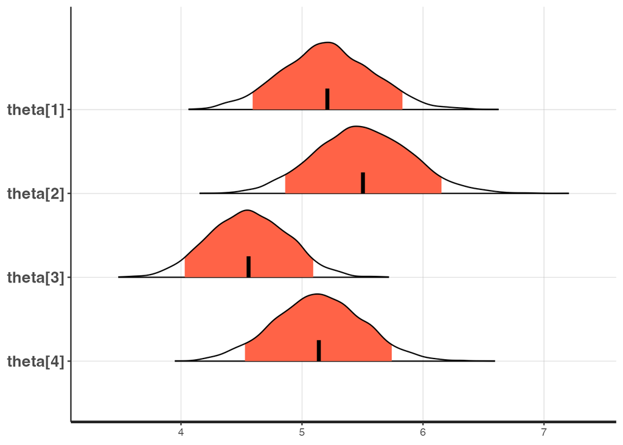

```r
stan_plot(
  fit,
  point_est = 'mean',
  show_density = TRUE,
  ci_level = 0.9,
  outer_level = 1,
  pars = 'theta',
  fill_color = 'tomato'
)
```

事後分布の値をもとに、各プレイヤーごとの強さに差がある確率を計算する。事後分布の値を引き算し、0より大きければ、そのプレイヤーの方が強いことになるため、MCMCサンプルの回数分、計算する。

```r
theta <- rstan::extract(fit)$theta

computeProb <- function(parameter, i, j){
  temp <- parameter[, i] - parameter[, j] > 0
  return(sum(temp) / length(temp))
}

mat <- matrix(0, nrow = playerNum, ncol = playerNum)
rownames(mat) <- colnames(mat) <- c('playerA', 'playerB', 'playerC', 'playerD')

for (i in 1:playerNum) {
  for (j in 1:playerNum) {
    if (i != j) {
      mat[i, j] <- computeProb(theta, i, j)
    } else {
      mat[i, j] <- 1
      }
  }
}

round(mat,  2)
```

```
##         playerA playerB playerC playerD
## playerA    1.00    0.12    1.00    0.61
## playerB    0.88    1.00    1.00    0.92
## playerC    0.00    0.00    1.00    0.01
## playerD    0.39    0.09    0.99    1.00
```

事後分布の可視化からプレイヤーBが強かったので、プレイヤーBを参考にすると、プレイヤーBは、プレイヤーAよりも88％強く、プレイヤーCよりも100％強く、プレイヤーDよりも92％強いことがわかる。まとめると、プレイヤーBは他のプレイヤーよりも93％強い。

```r
(
  sum(theta[,2] - theta[,1] > 0) +
  sum(theta[,2] - theta[,3] > 0) +
  sum(theta[,2] - theta[,4] > 0)
) / (nrow(theta)*3)
```

```
## [1] 0.9304167
```